# Homework 6

STAT 486/586 – Introduction to Statistical Computing

[Yuhang (Tom) LIN](https://sites.google.com/view/yuhangtom/)

Due: March 10, 2022

```r
library(purrr)
library(stringr)   ### For str_c
```

# Applying functions

## 1.

**(Not graded)**

### a.

```r
n <- 100

sum(map_dbl(1: n, function(x){
  1 / x
}))
```

```
[1] 5.187378
```

### b.

```r
n <- 100
m <- 50

sum(unlist(map(1:m, function(j) {
  map(1:n, function(i) {
    2^(-i * j)
  })
})))
```

```
[1] 1.606695
```

### c.

#### Part a.

```r
### Set a large n
n <- 1e7

### map time
system.time({
  sum(map_dbl(1:n, function(x) {
    1 / x
  }))
})
```

```
   user  system elapsed
   4.94    0.01    4.95
```

```r
### for loop time
system.time({
  out <- 0

  for (i in 1:n){
    out <- out + 1 / i
  }
  out
})
```

```
   user  system elapsed
   0.18    0.00    0.18
```

```r
### Vectorized operation time
system.time({
  i <- 1:n
  sum(1 / i)
})
```

```
   user  system elapsed
   0.03    0.00    0.03
```

#### Part b.

```r
### Initialization
n <- 1e4
m <- 1e3

### map time
system.time({
  sum(unlist(map(1:m, function(j) {
    map(1:n, function(i) {
      2^(-i * j)
    })
  })))
})
```

```
   user  system elapsed
   9.62    0.20    9.83
```

```r
### Nested for loop time
system.time({
  out <- 0

  for (i in 1:n){
    for (j in 1:m){
      out <- out + 2^(- i * j)
    }
  }
  out
})
```

```
   user  system elapsed
   1.14    0.00    1.14
```

```r
### Vectorized operation 1 time
system.time({
  ind <- matrix(1:n) %*% matrix(1:m, 1)
  sum(2^(- ind))
})
```

```
   user  system elapsed
   0.88    0.00    0.87
```

```r
### Vectorized operation 2 time
system.time({
  ind <- matrix(1:n, nrow = n, ncol = m) * matrix(1:m, nrow = n, ncol = m, byrow = TRUE)
  sum(2^(- ind))
})
```

```
   user  system elapsed
   0.96    0.00    0.97
```

```r
### Vectorized operation 3 time
system.time({
  ind <- outer(1:n, 1:m, "*")
  sum(2^(- ind))
})
```

```
   user  system elapsed
   0.91    0.00    0.91
```

As we can see, surprisingly, `map` is the slowest among these three, while the vectorized operation is the fastest. The `map` is useful for functional programming. We use it for its consistency in the format of input and output, as well as its concision when coding, which sacrifices a little bit of computation time. That is not a really big problem for usual simulations.

## 2.

**(Not graded)**

### a.

```r
str(mtcars)
```

```
'data.frame':   32 obs. of  11 variables:
 $ mpg : num  21 21 22.8 21.4 18.7 18.1 14.3 24.4 22.8 19.2 ...
 $ cyl : num  6 6 4 6 8 6 8 4 4 6 ...
 $ disp: num  160 160 108 258 360 ...
 $ hp  : num  110 110 93 110 175 105 245 62 95 123 ...
 $ drat: num  3.9 3.9 3.85 3.08 3.15 2.76 3.21 3.69 3.92 3.92 ...
 $ wt  : num  2.62 2.88 2.32 3.21 3.44 ...
 $ qsec: num  16.5 17 18.6 19.4 17 ...
 $ vs  : num  0 0 1 1 0 1 0 1 1 1 ...
 $ am  : num  1 1 1 0 0 0 0 0 0 0 ...
 $ gear: num  4 4 4 3 3 3 3 4 4 4 ...
 $ carb: num  4 4 1 1 2 1 4 2 2 4 ...
```

```r
map_dbl(mtcars, median)
```

```
    mpg     cyl    disp      hp    drat      wt    qsec      vs      am    gear
 19.200   6.000 196.300 123.000   3.695   3.325  17.710   0.000   0.000   4.000
   carb
  2.000
```

### b.

```r
do.call(rbind, map(split(mtcars, mtcars$cyl), colMeans))
```

```
       mpg cyl     disp        hp     drat       wt     qsec        vs
4 26.66364   4 105.1364  82.63636 4.070909 2.285727 19.13727 0.9090909
6 19.74286   6 183.3143 122.28571 3.585714 3.117143 17.97714 0.5714286
8 15.10000   8 353.1000 209.21429 3.229286 3.999214 16.77214 0.0000000
         am     gear     carb
4 0.7272727 4.090909 1.545455
6 0.4285714 3.857143 3.428571
8 0.1428571 3.285714 3.500000
```

### c.

```r
str(classdata::cities)
```

```
'data.frame':   1207 obs. of  14 variables:
 $ City               : chr  "Adel" "Albia" "Ames" "Amosa" ...
 $ Population         : int  4067 3699 52541 5646 36876 2464 32059 2611 12899 25571 ...
 $ Violent.crime      : int  3 9 147 5 36 0 75 2 33 120 ...
 $ Murder             : int  0 0 0 0 0 0 1 0 0 1 ...
 $ Rape               : int  0 0 24 0 6 0 9 1 15 8 ...
 $ Robbery            : int  0 0 17 0 6 0 13 0 0 13 ...
 $ Aggravated.assault : int  3 9 106 5 24 0 52 1 18 98 ...
 $ Property.crime     : int  114 67 1465 99 806 18 832 23 412 1226 ...
 $ Burglary           : int  13 11 363 16 140 10 156 7 112 296 ...
 $ Larceny.theft      : int  93 53 1061 81 626 4 644 15 285 881 ...
 $ Motor.vehicle.theft: int  8 3 41 2 40 4 32 1 15 49 ...
 $ Arson              : int  0 2 5 3 4 0 6 0 3 23 ...
 $ State              : chr  "iowa" "iowa" "iowa" "iowa" ...
 $ Year               : int  2006 2006 2006 2006 2006 2006 2006 2006 2006 2006 ...
```

```r
map_chr(classdata::cities, class)
```

```
               City          Population       Violent.crime              Murder
        "character"           "integer"           "integer"           "integer"
               Rape             Robbery  Aggravated.assault      Property.crime
          "integer"           "integer"           "integer"           "integer"
           Burglary       Larceny.theft Motor.vehicle.theft               Arson
          "integer"           "integer"           "integer"           "integer"
              State                Year
        "character"           "integer"
```

### d.

```r
str(iris)
```

```
'data.frame':   150 obs. of  5 variables:
 $ Sepal.Length: num  5.1 4.9 4.7 4.6 5 5.4 4.6 5 4.4 4.9 ...
 $ Sepal.Width : num  3.5 3 3.2 3.1 3.6 3.9 3.4 3.4 2.9 3.1 ...
 $ Petal.Length: num  1.4 1.4 1.3 1.5 1.4 1.7 1.4 1.5 1.4 1.5 ...
 $ Petal.Width : num  0.2 0.2 0.2 0.2 0.2 0.4 0.3 0.2 0.2 0.1 ...
 $ Species     : Factor w/ 3 levels "setosa","versicolor",..: 1 1 1 1 1 1 1 1 1 1 ...
```

```r
map_dbl(map(iris, unique), length)
```

```
Sepal.Length  Sepal.Width Petal.Length  Petal.Width      Species
          35           23           43           22            3
```

### e.

```r
map2_dbl(iris$Sepal.Length, iris$Sepal.Width, `*`)
```

```
  [1] 17.85 14.70 15.04 14.26 18.00 21.06 15.64 17.00 12.76 15.19 19.98 16.32
 [13] 14.40 12.90 23.20 25.08 21.06 17.85 21.66 19.38 18.36 18.87 16.56 16.83
 [25] 16.32 15.00 17.00 18.20 17.68 15.04 14.88 18.36 21.32 23.10 15.19 16.00
 [37] 19.25 17.64 13.20 17.34 17.50 10.35 14.08 17.50 19.38 14.40 19.38 14.72
 [49] 19.61 16.50 22.40 20.48 21.39 12.65 18.20 15.96 20.79 11.76 19.14 14.04
 [61] 10.00 17.70 13.20 17.69 16.24 20.77 16.80 15.66 13.64 14.00 18.88 17.08
 [73] 15.75 17.08 18.56 19.80 19.04 20.10 17.40 14.82 13.20 13.20 15.66 16.20
 [85] 16.20 20.40 20.77 14.49 16.80 13.75 14.30 18.30 15.08 11.50 15.12 17.10
 [97] 16.53 17.98 12.75 15.96 20.79 15.66 21.30 18.27 19.50 22.80 12.25 21.17
[109] 16.75 25.92 20.80 17.28 20.40 14.25 16.24 20.48 19.50 29.26 20.02 13.20
[121] 22.08 15.68 21.56 17.01 22.11 23.04 17.36 18.30 17.92 21.60 20.72 30.02
[133] 17.92 17.64 15.86 23.10 21.42 19.84 18.00 21.39 20.77 21.39 15.66 21.76
[145] 22.11 20.10 15.75 19.50 21.08 17.70
```

### f.

```r
pmap_dbl(iris[-5], sum)
```

```
  [1] 10.2  9.5  9.4  9.4 10.2 11.4  9.7 10.1  8.9  9.6 10.8 10.0  9.3  8.5 11.2
 [16] 12.0 11.0 10.3 11.5 10.7 10.7 10.7  9.4 10.6 10.3  9.8 10.4 10.4 10.2  9.7
 [31]  9.7 10.7 10.9 11.3  9.7  9.6 10.5 10.0  8.9 10.2 10.1  8.4  9.1 10.7 11.2
 [46]  9.5 10.7  9.4 10.7  9.9 16.3 15.6 16.4 13.1 15.4 14.3 15.9 11.6 15.4 13.2
 [61] 11.5 14.6 13.2 15.1 13.4 15.6 14.6 13.6 14.4 13.1 15.7 14.2 15.2 14.8 14.9
 [76] 15.4 15.8 16.4 14.9 12.8 12.8 12.6 13.6 15.4 14.4 15.5 16.0 14.3 14.0 13.3
 [91] 13.7 15.1 13.6 11.6 13.8 14.1 14.1 14.7 11.7 13.9 18.1 15.5 18.1 16.6 17.5
[106] 19.3 13.6 18.3 16.8 19.4 16.8 16.3 17.4 15.2 16.1 17.2 16.8 20.4 19.5 14.7
[121] 18.1 15.3 19.2 15.7 17.8 18.2 15.6 15.8 16.9 17.6 18.2 20.1 17.0 15.7 15.7
[136] 19.1 17.7 16.8 15.6 17.5 17.8 17.4 15.5 18.2 18.2 17.2 15.7 16.7 17.3 15.8
```

```r
pmap_dbl(iris[-5], function(Sepal.Length, Sepal.Width, Petal.Length, Petal.Width){
  Sepal.Length + Sepal.Width + Petal.Length + Petal.Width
})
```

```
  [1] 10.2  9.5  9.4  9.4 10.2 11.4  9.7 10.1  8.9  9.6 10.8 10.0  9.3  8.5 11.2
 [16] 12.0 11.0 10.3 11.5 10.7 10.7 10.7  9.4 10.6 10.3  9.8 10.4 10.4 10.2  9.7
 [31]  9.7 10.7 10.9 11.3  9.7  9.6 10.5 10.0  8.9 10.2 10.1  8.4  9.1 10.7 11.2
 [46]  9.5 10.7  9.4 10.7  9.9 16.3 15.6 16.4 13.1 15.4 14.3 15.9 11.6 15.4 13.2
 [61] 11.5 14.6 13.2 15.1 13.4 15.6 14.6 13.6 14.4 13.1 15.7 14.2 15.2 14.8 14.9
 [76] 15.4 15.8 16.4 14.9 12.8 12.8 12.6 13.6 15.4 14.4 15.5 16.0 14.3 14.0 13.3
 [91] 13.7 15.1 13.6 11.6 13.8 14.1 14.1 14.7 11.7 13.9 18.1 15.5 18.1 16.6 17.5
[106] 19.3 13.6 18.3 16.8 19.4 16.8 16.3 17.4 15.2 16.1 17.2 16.8 20.4 19.5 14.7
[121] 18.1 15.3 19.2 15.7 17.8 18.2 15.6 15.8 16.9 17.6 18.2 20.1 17.0 15.7 15.7
[136] 19.1 17.7 16.8 15.6 17.5 17.8 17.4 15.5 18.2 18.2 17.2 15.7 16.7 17.3 15.8
```

```r
temp <- iris
### Remove the entry names, otherwise call by names
names(temp) <- NULL
pmap_dbl(temp[-5], function(a, b, c, d){
  a + b + c + d
})
```

```
  [1] 10.2  9.5  9.4  9.4 10.2 11.4  9.7 10.1  8.9  9.6 10.8 10.0  9.3  8.5 11.2
 [16] 12.0 11.0 10.3 11.5 10.7 10.7 10.7  9.4 10.6 10.3  9.8 10.4 10.4 10.2  9.7
 [31]  9.7 10.7 10.9 11.3  9.7  9.6 10.5 10.0  8.9 10.2 10.1  8.4  9.1 10.7 11.2
 [46]  9.5 10.7  9.4 10.7  9.9 16.3 15.6 16.4 13.1 15.4 14.3 15.9 11.6 15.4 13.2
 [61] 11.5 14.6 13.2 15.1 13.4 15.6 14.6 13.6 14.4 13.1 15.7 14.2 15.2 14.8 14.9
 [76] 15.4 15.8 16.4 14.9 12.8 12.8 12.6 13.6 15.4 14.4 15.5 16.0 14.3 14.0 13.3
 [91] 13.7 15.1 13.6 11.6 13.8 14.1 14.1 14.7 11.7 13.9 18.1 15.5 18.1 16.6 17.5
[106] 19.3 13.6 18.3 16.8 19.4 16.8 16.3 17.4 15.2 16.1 17.2 16.8 20.4 19.5 14.7
[121] 18.1 15.3 19.2 15.7 17.8 18.2 15.6 15.8 16.9 17.6 18.2 20.1 17.0 15.7 15.7
[136] 19.1 17.7 16.8 15.6 17.5 17.8 17.4 15.5 18.2 18.2 17.2 15.7 16.7 17.3 15.8
```

```r
### Check
rowSums(iris[-5])
```

```
  [1] 10.2  9.5  9.4  9.4 10.2 11.4  9.7 10.1  8.9  9.6 10.8 10.0  9.3  8.5 11.2
 [16] 12.0 11.0 10.3 11.5 10.7 10.7 10.7  9.4 10.6 10.3  9.8 10.4 10.4 10.2  9.7
 [31]  9.7 10.7 10.9 11.3  9.7  9.6 10.5 10.0  8.9 10.2 10.1  8.4  9.1 10.7 11.2
 [46]  9.5 10.7  9.4 10.7  9.9 16.3 15.6 16.4 13.1 15.4 14.3 15.9 11.6 15.4 13.2
 [61] 11.5 14.6 13.2 15.1 13.4 15.6 14.6 13.6 14.4 13.1 15.7 14.2 15.2 14.8 14.9
 [76] 15.4 15.8 16.4 14.9 12.8 12.8 12.6 13.6 15.4 14.4 15.5 16.0 14.3 14.0 13.3
 [91] 13.7 15.1 13.6 11.6 13.8 14.1 14.1 14.7 11.7 13.9 18.1 15.5 18.1 16.6 17.5
[106] 19.3 13.6 18.3 16.8 19.4 16.8 16.3 17.4 15.2 16.1 17.2 16.8 20.4 19.5 14.7
[121] 18.1 15.3 19.2 15.7 17.8 18.2 15.6 15.8 16.9 17.6 18.2 20.1 17.0 15.7 15.7
[136] 19.1 17.7 16.8 15.6 17.5 17.8 17.4 15.5 18.2 18.2 17.2 15.7 16.7 17.3 15.8
```

## 3.

```r
library(repurrrsive)
```

### a.

```r
### Character names
(chr.name <- map_chr(got_chars, `[[`, "name"))
```

```
 [1] "Theon Greyjoy"      "Tyrion Lannister"   "Victarion Greyjoy"
 [4] "Will"               "Areo Hotah"         "Chett"
 [7] "Cressen"            "Arianne Martell"    "Daenerys Targaryen"
[10] "Davos Seaworth"     "Arya Stark"         "Arys Oakheart"
[13] "Asha Greyjoy"       "Barristan Selmy"    "Varamyr"
[16] "Brandon Stark"      "Brienne of Tarth"   "Catelyn Stark"
[19] "Cersei Lannister"   "Eddard Stark"       "Jaime Lannister"
[22] "Jon Connington"     "Jon Snow"           "Aeron Greyjoy"
[25] "Kevan Lannister"    "Melisandre"         "Merrett Frey"
[28] "Quentyn Martell"    "Samwell Tarly"      "Sansa Stark"
```

```r
### Actor names
(act.name <- map_chr(map(got_chars, `[[`, "playedBy"), str_c, collapse = ", "))
```

```
 [1] "Alfie Allen"
 [2] "Peter Dinklage"
 [3] ""
 [4] "Bronson Webb"
 [5] "DeObia Oparei"
 [6] ""
 [7] "Oliver Ford"
 [8] ""
 [9] "Emilia Clarke"
[10] "Liam Cunningham"
[11] "Maisie Williams"
[12] ""
[13] "Gemma Whelan"
[14] "Ian McElhinney"
[15] ""
[16] "Isaac Hempstead-Wright"
[17] "Gwendoline Christie"
[18] "Michelle Fairley"
[19] "Lena Headey"
[20] "Sean Bean, Sebastian Croft, Robert Aramayo"
[21] "Nikolaj Coster-Waldau"
[22] ""
[23] "Kit Harington"
[24] "Michael Feast"
[25] "Ian Gelder"
[26] "Carice van Houten"
[27] ""
[28] ""
[29] "John Bradley-West"
[30] "Sophie Turner"
```

### b.

**(Not graded)**

```r
### File names
Q3bfile.name <- str_c(chr.name, ".txt", sep = "")

### Save txt files
walk2(act.name, Q3bfile.name, writeLines)
```

### c.

```r
### File names
Q3cfile.name <- str_c(chr.name, "All.txt", sep = "")

### Method 1 (with imap)
cont <- map(got_chars, function(x) {
  ### Connect with formatting
  str_c(
    ### Connect text without "\n" in each entry
    imap_chr(x, function(x, i) {
      str_c(i, str_c(x, collapse = ", "), sep = ": ")
    }),
    collapse = "\n"
  )
})
### Save txt files
walk2(cont, Q3cfile.name, writeLines)


### Method 2 (without imap)
### Connect vectors in each entries
cont.dat <- map(got_chars, map_chr, str_c, collapse = ", ")
### Get sublist entry name
name.dat <- map(got_chars, names)
### Format the result
cont <- map2(name.dat, cont.dat, str_c, sep = ": ", collapse="\n")

### Save txt files
walk2(cont, Q3cfile.name, writeLines)
```

## 4.

**(Not graded)**

```r
l <- list(
  matrix(c(2, 3,
           4, 5), 2, 2),
  diag(c(1, 2)),
  diag(c(-2, 1))
)
```

### a.

```r
reduce(l, `%*%`)
```

```
     [,1] [,2]
[1,]   -4    8
[2,]   -6   10
```

### b.

```r
accumulate(l, `+`)
```

```
[[1]]
     [,1] [,2]
[1,]    2    4
[2,]    3    5

[[2]]
     [,1] [,2]
[1,]    3    4
[2,]    3    7

[[3]]
     [,1] [,2]
[1,]    1    4
[2,]    3    8
```

# Advanced functions

## 1.

### a.

```r
x <- 10
f1 <- function(x) {
  function() {
    x + 10
  }
}
g <- f1(1)
g()
```

```
[1] 11
```

Masking. `x` assigned in `f1`, which is `1`, mask `x` defined outside `f1` (in the global environment), which is `10`.

### b.

```r
y <- 2
i1<- function() {
  z <- 3
  c(y, z)
}
y <- 3
i1()
```

```
[1] 3 3
```

Dynamic lookup. `R` looks up the value of `y` when `i1` runs. The `y` in the global environment has been updated to `3` at that step.

### c.

**(Not graded)**

```r
f <- function(x) print("ha")
g <- function(y) print("hello")
y = f()
```

```
[1] "ha"
```

```r
g(y)
```

```
[1] "hello"
```

Functions are ordinary variables and lazy evaluation. Functions can be assigned. `y` in `g` is not evaluated because it is not accessed in `g`.

### d.

```r
f <- function(x) print("ha")
g <- function(y) print("hello")
g(y = f())
```

```
[1] "hello"
```

Lazy evaluation. Only `g` is evaluated, `y` in `g` is not evaluated because it is not accessed in `g`.

## 2.

### a.

```r
### Method 1
getf <- function(a) {
  ### Force evaluate a
  force(a)

  function(x) {
    ### Apply to vector x
    map_dbl(x, function(x) {
      ### Create polynomial
      do.call(
        sum,
        ### Create summand
        imap(a, function(a, i) {
          a * x^(i - 1)
        })
      )
    })
  }
}

### Method 2 (simpler)
getf <- function(a){
  ### Force evaluate a
  force(a)

  function(x){
    ### Apply to vector x
    map_dbl(x, function(x){
      ### Create polynomial
      sum(a * x ^ (0: (length(a) - 1)))
    })
  }
}
```

### b.

**(Not graded)**

#### i.

```r
### Scaler input
testthat::expect_equal(class(getf(1)), "function")
### Vector input
testthat::expect_equal(class(getf(1:10)), "function")
```

#### ii.

```r
### Vector input
a <- 2
x <- 1: 10
getf(a)(x)
```

```
 [1] 2 2 2 2 2 2 2 2 2 2
```

```r
### Unit test
testthat::expect_equal(getf(a)(x), rep(a, length(x)))

### Scaler input
a <- 2
x <- 10
getf(a)(x)
```

```
[1] 2
```

```r
### Unit test
testthat::expect_equal(getf(a)(x), rep(a, length(x)))
```

#### iii.

```r
### Vector input
a <- c(1, -1)
x <- 1: 10
getf(a)(x)
```

```
 [1]  0 -1 -2 -3 -4 -5 -6 -7 -8 -9
```

```r
### Unit test
testthat::expect_equal(getf(a)(x), 1 - x)

### Scaler input
a <- c(1, -1)
x <- 10
getf(a)(x)
```

```
[1] -9
```

```r
### Unit test
testthat::expect_equal(getf(a)(x), 1 - x)
```

### c.

```r
a <- c(1, 0, 1)
f <- getf(a)
l <- 0
u <- 10
integrate(f, lower = l, upper = u)
```

```
343.3333 with absolute error < 3.8e-12
```

```r
### Unit test
### Expected value from calculus
testthat::expect_equal(integrate(f, lower = l, upper = u)$value, u + 1/3 * u ^ 3)
```

### d.

**(Not graded)**

```r
getint <- function(a, lower, upper){
  ### Force evaluate a
  force(a)

  f <- function(x){
    ### Apply to vector x
    map_dbl(x, function(x){
      ### Create polynomial
      sum(a * x ^ (0: (length(a) - 1)))
    })
  }

  ### Integrate
  integrate(f, lower = l, upper = u)
}

### Unit test
a <- c(1, 0, 1)
l <- 0
u <- 10
getint(a = a, lower = l, upper = u)
```

```
343.3333 with absolute error < 3.8e-12
```

```r
### Unit test
### Expected value from calculus
testthat::expect_equal(getint(a = a, lower = l, upper = u)$value, u + 1/3 * u ^ 3)
```

## 3. (Optional)

**(Not graded)**

### a.

```r
getl <- function(x) {
  force(x)

  function(par) {
    alp <- par[1]
    bet <- par[2]

    ### Joint log-likelihood
    sum(alp * log (bet) - lgamma(alp) + (alp - 1) * log (x) - bet * x)
    # dgamma
  }
}
```

### b.

```r
x <- c(0.289, 0.468, 0.035, 2.114, 0.281)
l <- getl(x)
```

### c.

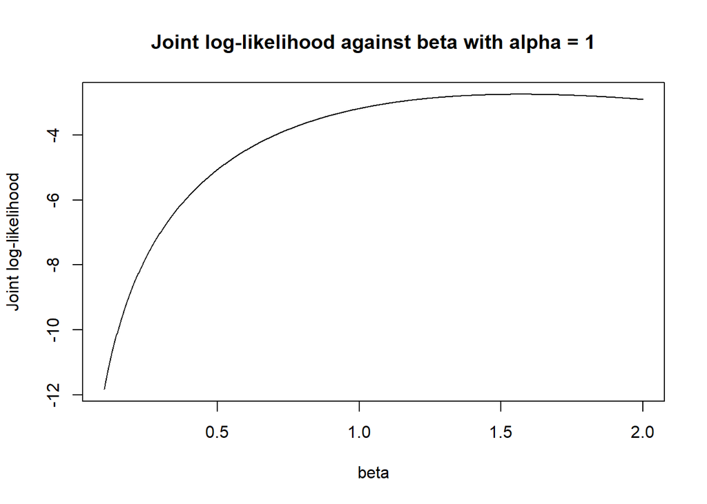

```r
### Method 1
alp <- 1
bet <- seq(0.1, 2, length.out = 1000)
### Each column is a pair for par
temp <- data.frame(rbind(alp, bet))
l.val <- map(temp, l)
plot(bet, l.val, type="l", xlab = "beta", ylab = "Joint log-likelihood", main = "Joint log-likelihood against beta with alpha = 1")
```

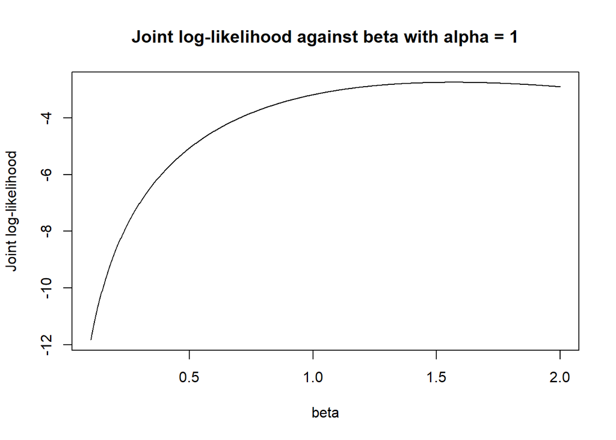

```r
### Method 2
alp <- 1
bet <- seq(0.1, 2, length.out = 1000)

l.val <- map(bet, function(x){
  l(c(alp, x))
})
plot(bet, l.val, type="l", xlab = "beta", ylab = "Joint log-likelihood", main = "Joint log-likelihood against beta with alpha = 1")
```

## 4. (Optional)

**(Not graded)**

```r
x <- c(0.104, 0.069, 0.034, 0.906, 0.75,
       0.484, 0.574, 1.747, 0.254, 0.591,
       0.088, 0.643, 0.754, 0.004, 0.495,
       1.499, 0.802, 0.495, 0.105, 0.64)
l <- getl(x)
(out <- optim(par = c(1, 1), fn = l, control = list(fnscale = -1)))
```

```
$par
[1] 0.9635267 1.7461073

$value
[1] -8.103168

$counts
function gradient
      59       NA

$convergence
[1] 0

$message
NULL
```

```r
### Maximum likelihood estimates
MLE <- out$par
names(MLE) <- c("alpha", "beta")
MLE
```

```
    alpha      beta
0.9635267 1.7461073
```

Convergence code `0` indicates successful completion.